# Peer Assessment 1

SLT

October 8, 2015

This is the documentation for Peer Assessment 1 as part of Reproducible Results. The data can be downloaded from https://d396qusza40orc.cloudfront.net/repdata%2Fdata%2Factivity.zip. This code assumes the data has been downloaded and unzipped in your working directory. The data file is activity.csv.

# Loading and Preprocessing the data

```r
data <- read.csv("activity.csv",header=TRUE)
```

# What is mean total number of steps taken per day?

Calculate the total number of steps. Remove the NAs, so some days will have 0 steps. Print the head and tail of the result.

```r
library(dplyr)
dates <- group_by(data,date)
dates_total <- summarize(dates, total = sum(steps,na.rm=TRUE))
head(dates_total)
```

```
## Source: local data frame [6 x 2]
##
##         date total
## 1 2012-10-01     0
## 2 2012-10-02   126
## 3 2012-10-03 11352
## 4 2012-10-04 12116
## 5 2012-10-05 13294
## 6 2012-10-06 15420
```

```r
tail(dates_total)
```

```
## Source: local data frame [6 x 2]
##
##         date total
## 1 2012-11-25 11834
## 2 2012-11-26 11162
## 3 2012-11-27 13646
## 4 2012-11-28 10183
## 5 2012-11-29  7047
## 6 2012-11-30     0
```

Histogram of the total number of steps taken each day

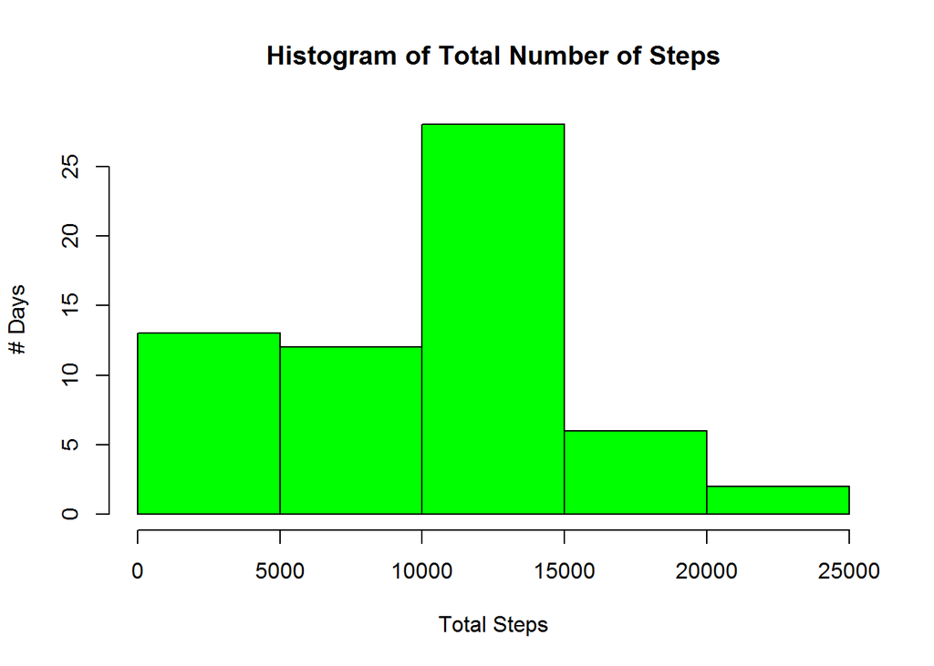

Calculate the mean and median of the total number of steps taken per day

```r
dates <- group_by(data, date)
mean_median <- summarize(dates, mean = mean (steps, na.rm=TRUE), median = median (steps, na.rm=TRUE))
print(tbl_df(mean_median),n=nrow(mean_median))
```

```
## Source: local data frame [61 x 3]
##
##          date       mean median
## 1  2012-10-01        NaN     NA
## 2  2012-10-02  0.4375000      0
## 3  2012-10-03 39.4166667      0
## 4  2012-10-04 42.0694444      0
## 5  2012-10-05 46.1597222      0
## 6  2012-10-06 53.5416667      0
## 7  2012-10-07 38.2465278      0
## 8  2012-10-08        NaN     NA
## 9  2012-10-09 44.4826389      0
## 10 2012-10-10 34.3750000      0
## 11 2012-10-11 35.7777778      0
## 12 2012-10-12 60.3541667      0
```

[output cut: 49 more lines]

# What is the average daily activity pattern?

Calculate average number of steps taken across all days

```r
data$interval <- as.factor(data$interval)
int <- group_by(data,interval)
interval_avg <- summarize(int, mean = mean(steps,na.rm=TRUE))
```

Time series plot of the 5-minute interval and the average number of steps taken, averaged across all days.

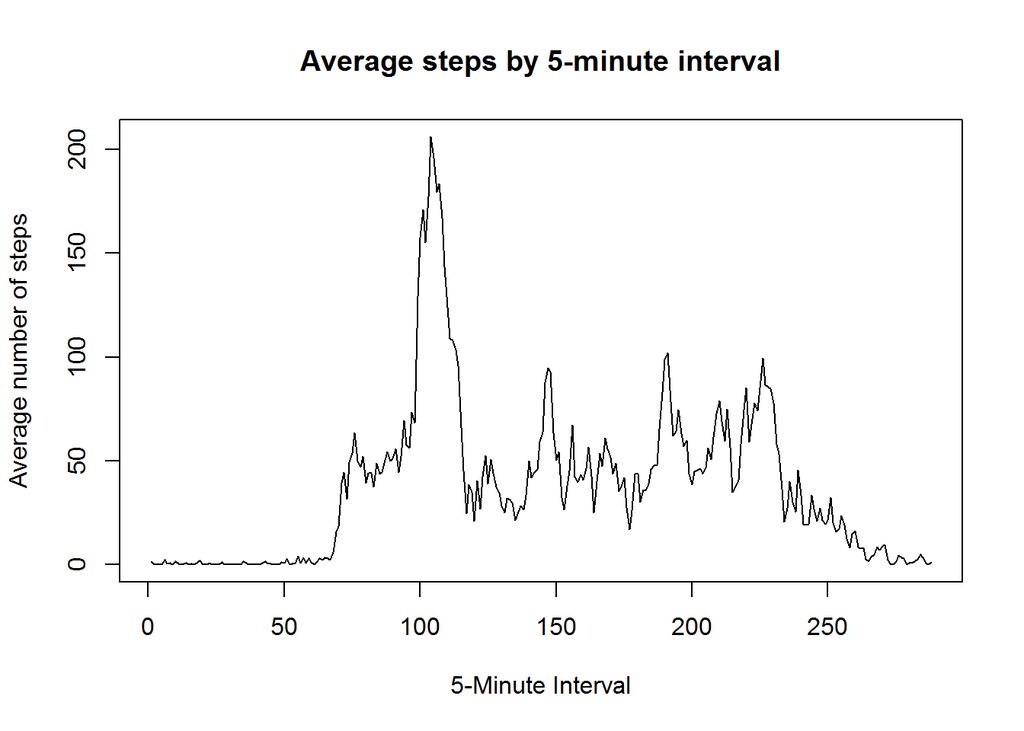

Calculate interval with the maximum average number of steps

```r
interval_avg[which.max(interval_avg$mean),]
```

```
## Source: local data frame [1 x 2]
##
##   interval     mean
## 1      835 206.1698
```

# Imputing missing values

Calculate and report the total number of day/interval combinations that are missing values

```r
sum(is.na(data$steps))
```

```
## [1] 2304
```

Use the mean for the interval to fill in the missing NAs Calculate the total number of steps each day using the new data set

```r
new_data <- data %>% group_by(interval) %>% mutate(steps=replace(steps,is.na(steps),mean(steps,na.rm=TRUE)))
dates <- group_by(new_data,date)
dates_total <- summarize(dates,total = sum(steps,na.rm=TRUE))
head(dates_total)
```

```
## Source: local data frame [6 x 2]
##
##         date    total
## 1 2012-10-01 10766.19
## 2 2012-10-02   126.00
## 3 2012-10-03 11352.00
## 4 2012-10-04 12116.00
## 5 2012-10-05 13294.00
## 6 2012-10-06 15420.00
```

```r
tail(dates_total)
```

```
## Source: local data frame [6 x 2]
##
##         date    total
## 1 2012-11-25 11834.00
## 2 2012-11-26 11162.00
## 3 2012-11-27 13646.00
## 4 2012-11-28 10183.00
## 5 2012-11-29  7047.00
## 6 2012-11-30 10766.19
```

Histogram of the total number of steps taken each day using the new data set

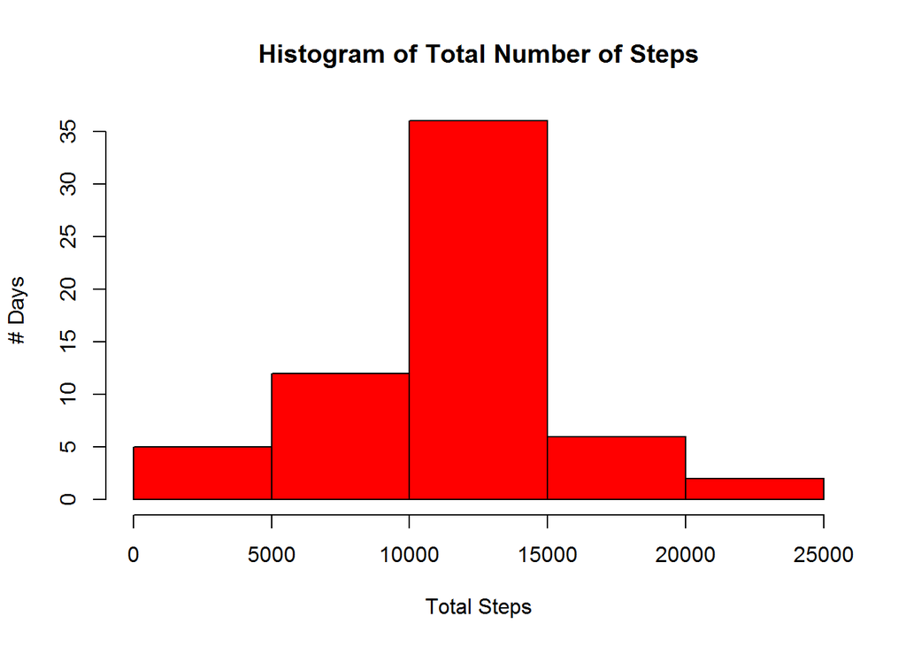

```r
dates <- group_by(new_data, date)
mean_median2 <- summarize(dates, mean2 = mean (steps, na.rm=TRUE), median2 = median (steps, na.rm=TRUE))
print(tbl_df(mean_median2),n=nrow(mean_median2))
```

```
## Source: local data frame [61 x 3]
##
##          date      mean2  median2
## 1  2012-10-01 37.3825996 34.11321
## 2  2012-10-02  0.4375000  0.00000
## 3  2012-10-03 39.4166667  0.00000
## 4  2012-10-04 42.0694444  0.00000
## 5  2012-10-05 46.1597222  0.00000
## 6  2012-10-06 53.5416667  0.00000
## 7  2012-10-07 38.2465278  0.00000
## 8  2012-10-08 37.3825996 34.11321
## 9  2012-10-09 44.4826389  0.00000
## 10 2012-10-10 34.3750000  0.00000
## 11 2012-10-11 35.7777778  0.00000
## 12 2012-10-12 60.3541667  0.00000
```

[output cut: 49 more lines]

# Are there differences in activity patterns between weekdays and weekends?

Compare activity patterns between weekdays and weekend. Create a new variable in the dataset with two levels - “weekday” and “weekend”.

```r
new_data <- mutate(new_data, date = as.Date(date, format = "%Y-%m-%d"))
new_data <- mutate(new_data, weekday = weekdays(date))
new_data$weekday[new_data$weekday == "Saturday" | new_data$weekday == "Sunday"] <- "weekend"
new_data$weekday[new_data$weekday != "weekend"] <- "weekday"
new_data$weekday <- as.factor(new_data$weekday)
#Create new column for timeseries ticks
new_data <- mutate (new_data, ticks = as.integer(interval)/5)
```

Panel plot containing a time series plot of the 5-minute interval (x-axis) and the average number of steps taken, averaged across all weekday days or weekend days (y-axis).

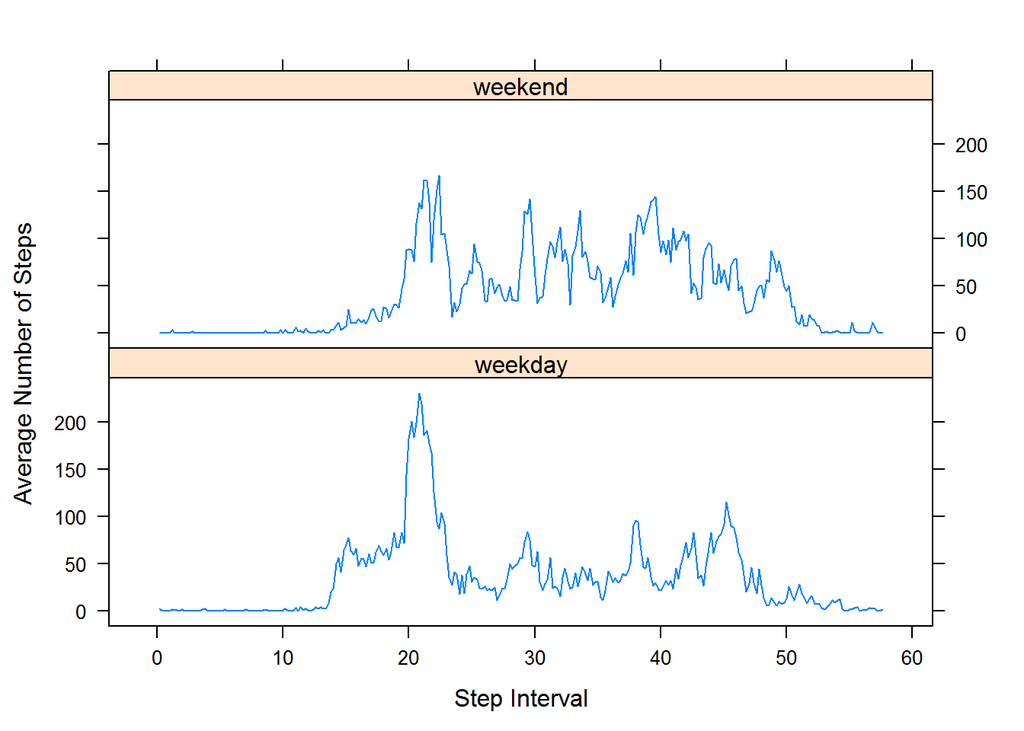